# Continuous Integration Smell Report

### Project: authorjapps/zerocode

This report was generated at 2018-08-16 19:47:54 UTC. We have analyzed the CI history of your project from your [Travis-CI build logs](https://travis-ci.org/authorjapps/zerocode) and your [GitHub repository](https://www.github.com/authorjapps/zerocode) and have checked several dimensions of your CI process to find deviations from accepted best practices. In the following, you will find the results of our analysis.

We would highly appreciate your feedback and constructive comments on this report. This helps us to evaluate the idea and to further improve the report in the future. Please consider taking the following [quick survey](http://www.surveygizmo.com/s3/4515476/Summarizing-the-Continuous-Integration-Process)

### Slow builds

### Broken release branch

### Skip failed tests

### Late merging

## Slow builds

Build times can increase due to high workload of the build server or due to increased project complexity over time. In fact, slow-down is often hard to detect, because it slowly creeps into the project. A slow build causes wait times for developers, adds a large overhead to the whole process, and should be avoided. Our summary provides an overview over recent build times and reports recent cases, in which the build duration takes substantially longer than usual.

#### ↗ Uptrend -

#### During the last 90 days, your build duration increased by 55.36%

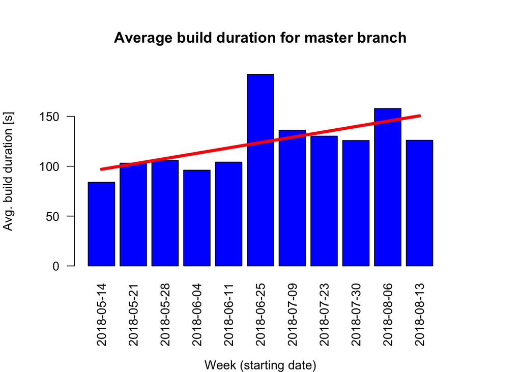

## Broken release branch

The CI pipeline requires a working build to properly assess whether changes introduce a problem, so recovering the build is the highest team priority. A build on the release branch typically also involves the deployment of the build results and should never fail. Our summary provides an overview over the number of recent release-branch failures and indicates the trend over time.

#### ↘ Downtrend -

#### Downtrend: during the last 90 days, the number of broken release builds decreased.

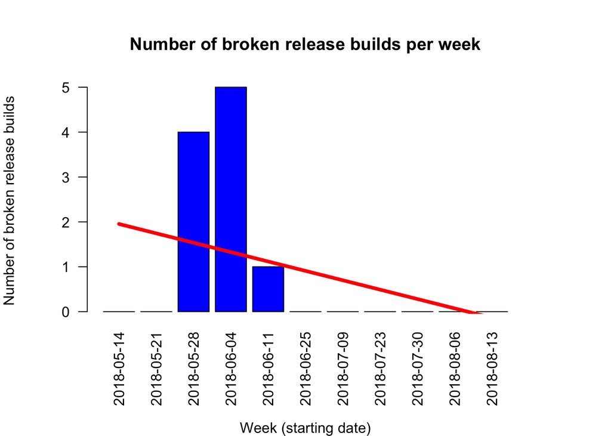

## Skip failed tests

Having an elaborated test-suite is one of the pillars of continuous integration. It provides protection from invalid changes and failing tests have to be taken seriously. Deleting or skipping a failing test might fix a broken build, but it is a removal of the symptom rather than a fix of the root cause and should be avoided.

#### Instead of fixing a failed test, we found 4 cases over the last 6 months, in which the failing test has simply been ignored

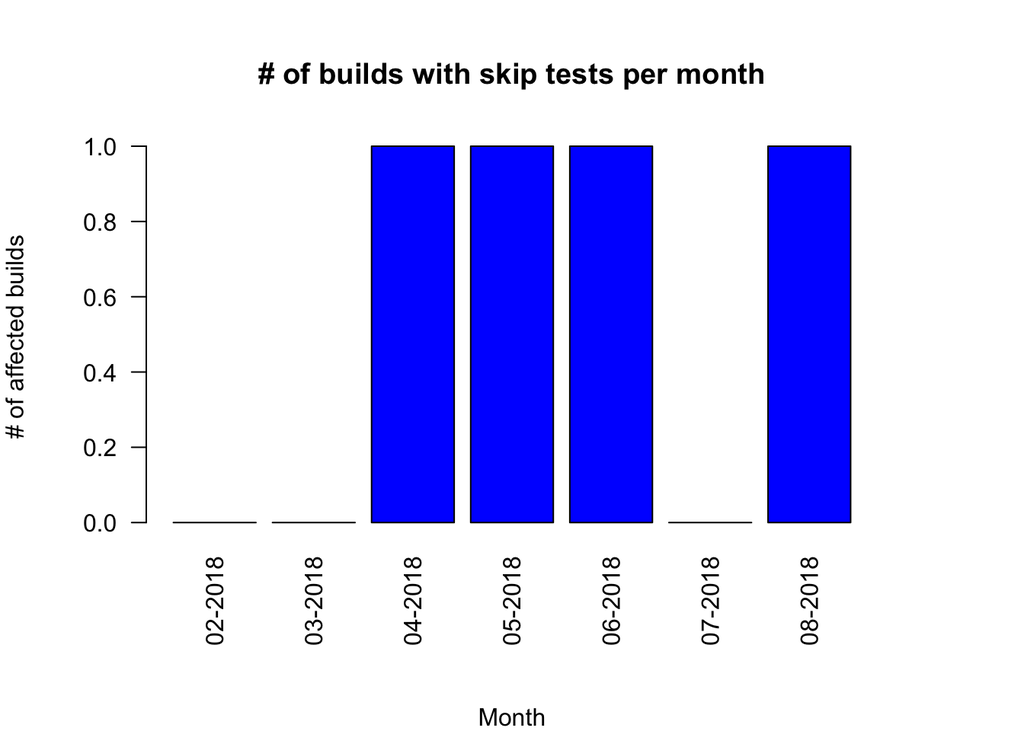

#### Recent cases, in which previously failing test cases have been ignored:

[output not shown]

## Late merging

Benefits of CI diminish, when individual feature branches are synchronized sparsely or when they are too long-lived. We point out several scenarios in our reports that might indicate such a ‘Late Merging’

##### Issues found for branch: ISS-00_step_images

[output not shown]

##### Issues found for branch: ISS-112_junit_test

| Severity | Description |
| --- | --- |
| High | You have been working on ISS-112_junit_test for 1.27 weeks.Your feature branches are typically open for 1.1 days. |

##### Issues found for branch: ISS-53_load_runner

[output not shown]

##### Issues found for branch: ISS-55_uuid

[output not shown]

##### Issues found for branch: ISS-67_custom_place_holder

[output not shown]

##### Issues found for branch: ISSUE-19_report_folder

[output not shown]

##### Tip: Frequently synchronized branches are easier to integrate.

##### Tip: Break features into smaller tasks to finish them faster.

Thanks for reading the summary! Please now fill our [quick survey](http://www.surveygizmo.com/s3/4515476/Summarizing-the-Continuous-Integration-Process)